# Презентация по первому этапу индивидуального проекта

Архитектура компьютеров и операционные системы

Вакутайпа М.

Российский университет дружбы народов, Москва, Россия

01 Марта 2024

# Цель работы

Быстрое развертывание сайта на GitHub Pages с помощью генератора статического html Hugo.

# Задание

- Установка программного обеспечения
- Установка темы
- Публикация сайта

# Выполнение работы

## Установка программного обеспечения

- Установливаю программу вручную с репозитория на Github:

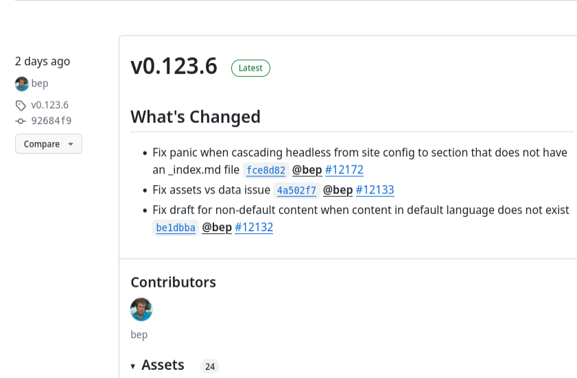

Установка Hugo

## Установка программного обеспечения

- Распаковаю программу и копирую её в bin:

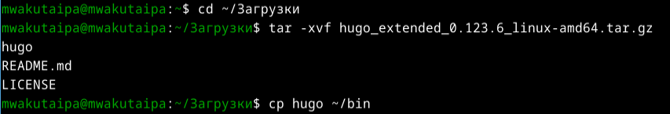

Распаковка

## Установка программного обеспечения

- По шаблону Academic-cv создаю новый репозиторий blog:

[figure not shown]

blog

## Установка программного обеспечения

- Клонирую репозиторий, который содержит структуру сайта в каталог work/blog :

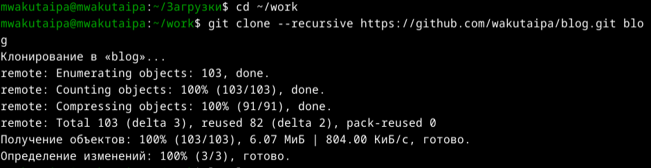

Клонирование

## Установка программного обеспечения

- Перехожу в этот же каталог и проверяю с помощью ls -l:

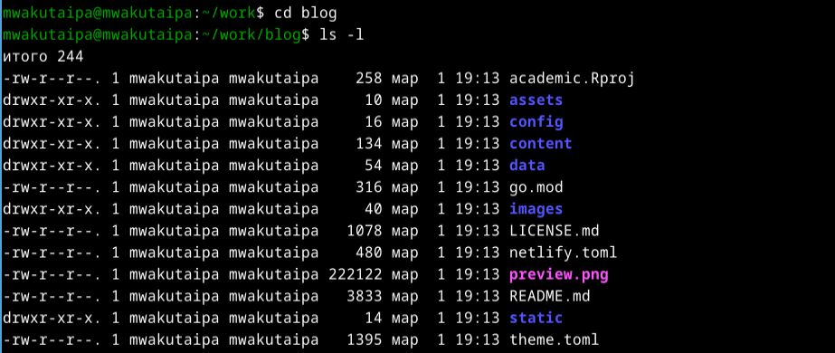

Проверка

## Установка темы

- Запускаю hugo:

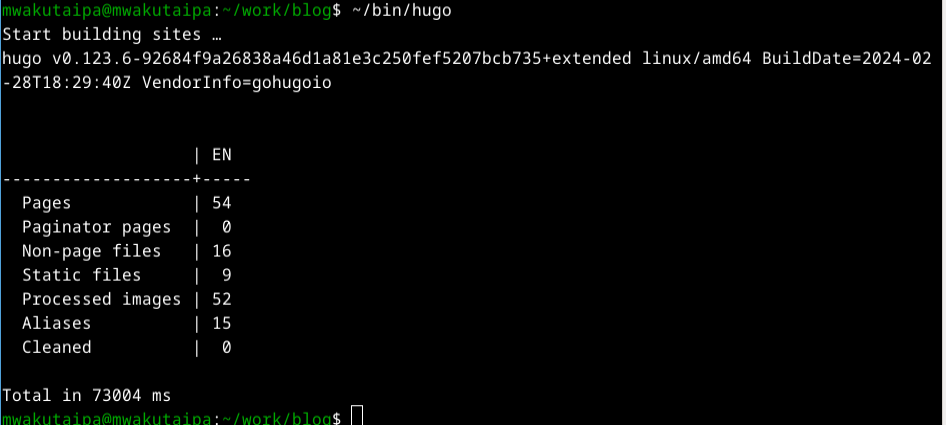

Запуск hugo

## Установка темы

- Запускаю программу с командой server, чтобы видеть сайт на локальный сервер:

## Установка темы

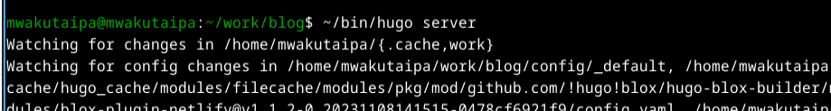

hugo server

## Установка темы

[figure not shown]

Сайт на локальном сервере

## Установка темы

- Создаю еще один репозиторий имя, которое является адресом сайта:

[figure not shown]

новый репозиторий

## Установка темы

- Клонирую созданный репозиторий, который храняется у себя в каталог wakutaipa.github.io:

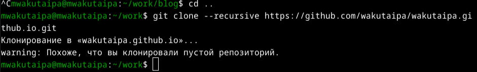

Клонирование

## Установка темы

- Создаю новую ветку с именем main:

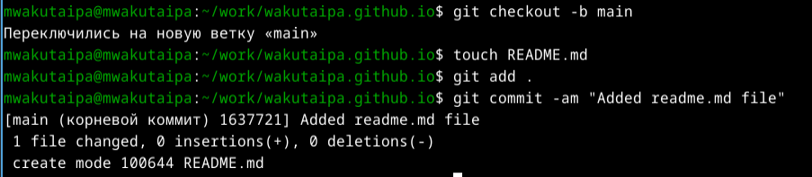

Новая ветка

## Публикация сайта

- Создаю пустой файл readme.md и отправляю на глобальный репозиторий:

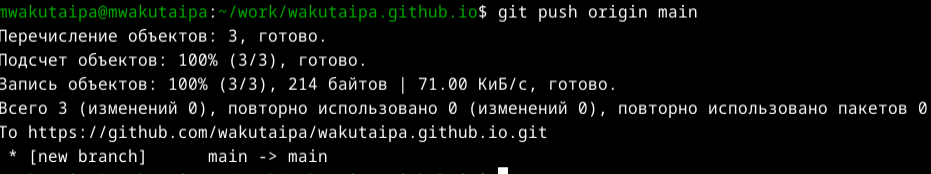

git push

## Публикация сайта

- Комментирую public с помощью mc в .gitignore чтобы каталоги с таким названием не игнорировались:

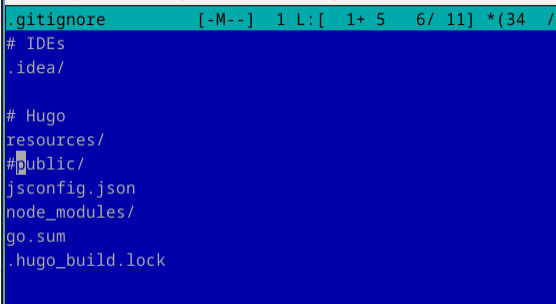

.gitignore

## Публикация сайта

- Добавляю репозиторий к каталогу с помощью git submodule add:

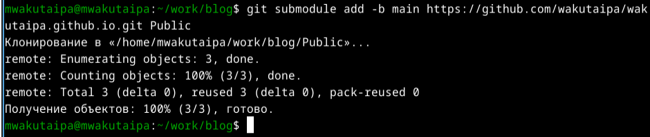

git submodule add

## Публикация сайта

- Запускаю hugo, чтобы заполнить созданный каталог:

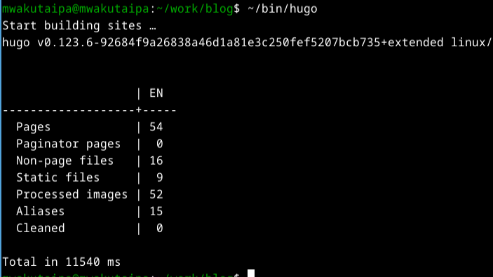

Запуск hugo

## Публикация сайта

- Провеяю подключение между созданным каталогом и wakutaipa.github.io:

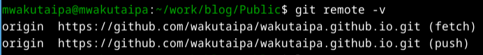

Проверка подключением

## Публикация сайта

Далее отправляю все файлы на github:

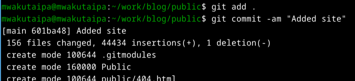

Отправка файлы

## Публикация сайта

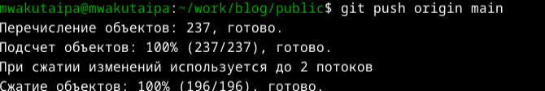

Отправка файлы

## Публикация сайта

[figure not shown]

# Выводы

При выполнении данной работы я научилась, как развмещать сайт на GitHub Pages с помощью генератора статического html Hugo.